# Studienarbeit Data Analytics

### Dozent: Prof. Dr. Fabian Brunner | Name: Nicolas Proske | Ausgabe: 08.06.2020 | Abgabe: 02.07.2020

## Gliederung

- **Aufgabe 0** (Imports und allgemeine Definitionen)
- **Aufgabe 1** (Messstationen, Datenakquise, Semistrukturierte Daten, Geovisualisierung)
  - Teilaufgabe a
  - Teilaufgabe b
  - Teilaufgabe c
  - Teilaufgabe d
  - Teilaufgabe e
- **Aufgabe 2** (NO2-Daten, Datenvorbereitung, Datenqualität)
  - Teilaufgabe a
  - Teilaufgabe b
  - Teilaufgabe c
  - Teilaufgabe d
  - Teilaufgabe e
  - Teilaufgabe f
- **Aufgabe 3** (Explorative Datenanalyse)
  - Teilaufgabe a
  - Teilaufgabe b
  - Teilaufgabe c
  - Teilaufgabe d
- **Aufgabe 4** (Verletzung der zulässigen NO2-Grenzwerte)
  - Teilaufgabe a
  - Teilaufgabe b
- **Aufgabe 5** (Visualisierung)
  - Teilaufgabe a
  - Teilaufgabe b
  - Teilaufgabe c
- **Aufgabe 6** (Interaktives Diagramm)
  - Teilaufgabe a
  - Teilaufgabe b
- **Aufgabe 7** (Abhängigkeit zwischen der Ozonkonzentration und der Temperatur)
  - Teilaufgabe a
  - Teilaufgabe b
  - Teilaufgabe c
  - Teilaufgabe d
  - Teilaufgabe e
  - Teilaufgabe f
  - Teilaufgabe g
  - Teilaufgabe h
- **Aufgabe 8** (Einfluss der Coronavirus-Pandemie auf die Luftqualität)
  - Teilaufgabe a
  - Teilaufgabe b
  - Teilaufgabe c
    - Hypothese 1
    - Hypothese 2
    - Hypothese 3
- **Zusammenfassung der Analyseergebnisse**

## Aufgabe 0:

> *Imports und allgemeine Definitionen*  
> **Zurück zur Gliederung**

```python
# Alle wichtigen Imports festlegen

import pandas as pd
import numpy as np

from matplotlib import pyplot as plt # Zur Erstellung von Plots

import plotly.graph_objects as go # Zur Erstellung des in Aufgabe 6 verlangten Säulendiagramms
import ipywidgets as widgets # Zur Erstellung der in Aufgabe 6 verlangten Radio-Buttons

import requests # Um HTTP Anfragen an UBA-API ausführen zu können

import folium # Interaktive Karte
from folium import plugins # Für Minimap auf interaktiver Karte

import os # Zur Erstellung eines neuen Ordners namens 'cache' (siehe unten)
from os import path # Zur Überprüfung, ob Datei im angegebenen Pfad existiert

%matplotlib inline

# Erstelle einen Cache-Ordner, in dem später alle heruntergeladenen API-Daten gespeichert werden
# Das hat den Vorteil, dass die Daten nur einmal von der API geladen werden müssen
if not os.path.exists('cache'):
    os.mkdir('cache')
```

## Aufgabe 1:

> *Messstationen, Datenakquise, Semistrukturierte Daten, Geovisualisierung*  
> **Zurück zur Gliederung**

**a) Aufgabenstellung**

Beziehen Sie über die Metadaten-API des Umweltbundesamts die Daten zu den Messstationen zum Stand 01.01.2020, indem Sie, z.B. unter Verwendung der Bibliothek `requests`, einen geeigneten HTTP-Request absetzen. Überführen Sie die erhaltenen (semistrukturierten) Daten in einen DataFrame namens `stations`, der für jede Station eine Zeile mit den verfügbaren Informationen enthält (z.B. Name, Adresse, Geokoordinaten, Bundesland etc.). Speichern Sie den DataFrame in eine CSV-Datei namens `stations_2020.csv` und laden Sie diese mit Ihrer Einreichung auf Moodle hoch.

```python
# Prüfen, ob die Daten bereits als CSV Datei vorliegen
if(path.exists('cache/stations_2020.csv')):
    stations = pd.read_csv('cache/stations_2020.csv')
else:
    # Definiere die spezifischen URL-Parameter
    payload = {'use': 'measure', 'lang': 'de', 'date_from': '2020-01-01', 'date_to': '2020-01-01'}

    # POST-HTTP-Request mit oben vordefinirten Parametern
    response = requests.post('https://www.umweltbundesamt.de/api/air_data/v2/meta/json', params=payload).json() # Umwandeln in JSON-Format

    # Überführung der JSON-Response in einen DataFrame mittels Pandas
    stations = pd.DataFrame(response['stations'],
                            index=[
                                'Id of station',
                                'Code of station',
                                'Name of station',
                                'City of station',
                                'Synonym of station',
                                'Date of first activity',
                                'Date of last activity',
                                'Longitude of station',
                                'Latitude of station',
                                'Id of network',
                                'Id of station setting',
                                'Id of station type',
                                'Code of network',
                                'Name of network',
                                'Name of station setting',
                                'Short name of station setting',
                                'Name of station type',
                                'Street of station',
                                'Street number of station',
                                'ZIP code of station',
                            ]).transpose() # Transpose bewirkt einen Wechsel der Zeilen & Spalten

    # Speichern des DataFrames als .csv-Datei
    stations.to_csv('cache/stations_2020.csv', index=False)

# Ersten 5 Einträge des DataFrames ausgeben
stations
```

|  | Id of station | Code of station | Name of station | City of station | Synonym of station | Date of first activity | Date of last activity | Longitude of station | Latitude of station | Id of network | Id of station setting | Id of station type | Code of network | Name of network | Name of station setting | Short name of station setting | Name of station type | Street of station | Street number of station | ZIP code of station |
| --- | --- | --- | --- | --- | --- | --- | --- | --- | --- | --- | --- | --- | --- | --- | --- | --- | --- | --- | --- | --- |
| 0 | 7 | DEBB007 | Elsterwerda | Elsterwerda | ELBA | 1992-09-01 | NaN | 13.5268 | 51.4627 | 4 | 2 | 1 | BB | Brandenburg | vorstädtisches Gebiet | vorstädtisch | Hintergrund | Lauchhammerstr. | NaN | 4910 |
| 1 | 21 | DEBB021 | Potsdam-Zentrum | Potsdam | PDBA | 2009-04-15 | NaN | 13.0599 | 52.4014 | 4 | 1 | 1 | BB | Brandenburg | städtisches Gebiet | städtisch | Hintergrund | Am Bassinplatz | NaN | 14467 |
| 2 | 28 | DEBB029 | Schwedt (Oder) | Schwedt/Oder | SWHE | 1993-04-06 | NaN | 14.2851 | 53.0643 | 4 | 2 | 2 | BB | Brandenburg | vorstädtisches Gebiet | vorstädtisch | Industrie | Helbigstr. | NaN | 16303 |
| 3 | 31 | DEBB032 | Eisenhüttenstadt | Eisenhüttenstadt | EHST | 1993-04-20 | NaN | 14.6382 | 52.1463 | 4 | 2 | 2 | BB | Brandenburg | vorstädtisches Gebiet | vorstädtisch | Industrie | Karl-Marx-Str. | 35 | 15890 |
| 4 | 42 | DEBB044 | Cottbus, Bahnhofstr. | Cottbus | COBA | 2012-09-25 | NaN | 14.3280 | 51.7566 | 4 | 1 | 3 | BB | Brandenburg | städtisches Gebiet | städtisch | Verkehr | Bahnhofstr. | 55 | 3046 |
| ... | ... | ... | ... | ... | ... | ... | ... | ... | ... | ... | ... | ... | ... | ... | ... | ... | ... | ... | ... | ... |
| 432 | 1973 | DEUB029 | Schmücke | Gehlberg | NaN | 1978-07-01 | NaN | 10.7695 | 50.6541 | 17 | 3 | 1 | UB | UBA | ländliches Gebiet | ländlich | Hintergrund | Schmücke | NaN | 98559 |
| 433 | 1974 | DEUB030 | Neuglobsow | Neuglobsow | NaN | 1969-01-01 | NaN | 13.0317 | 53.1413 | 17 | 5 | 1 | UB | UBA | ländlich regional | ländlich | Hintergrund | Zur alten Fischerhütte | 1 | 16775 |
| 434 | 1990 | DEUB046 | Forellenbach | Spiegelau | NaN | 2000-01-01 | NaN | 13.4206 | 48.9476 | 17 | 4 | 1 | UB | UBA | ländlich abgelegen | ländlich | Hintergrund | NaN | NaN | 94518 |
| 435 | 2113 | DEBB110 | Dallgow-Döberitz | Dallgow-Döberitz | NaN | 2019-06-19 | NaN | 13.0488 | 52.5395 | 4 | 2 | 1 | BB | Brandenburg | vorstädtisches Gebiet | vorstädtisch | Hintergrund | Am Egelpfuhl | NaN | 14624 |
| 436 | 9404 | DENW397 | Düsseldorf-Eller | Düsseldorf | DWER | 2019-08-22 | 2020-06-25 | 6.8175 | 51.2012 | 10 | 1 | 1 | NW | Nordrhein-Westfalen | städtisches Gebiet | städtisch | Hintergrund | Speyerweg | NaN | 40229 |

437 rows × 20 columns

**b) Aufgabenstellung**

Wie viele Messstationen sind derzeit bundesweit in Betrieb?

```python
print('Bundesweit sind derzeit insgesamt ' + str(len(stations)) + ' Messstationen in Betrieb.')
```

```
Bundesweit sind derzeit insgesamt 437 Messstationen in Betrieb.
```

**c) Aufgabenstellung**

Visualisieren Sie mit Hilfe eines Kreisdiagramms, wie sich die Stationen hinsichtlich ihres Typs zusammensetzen.

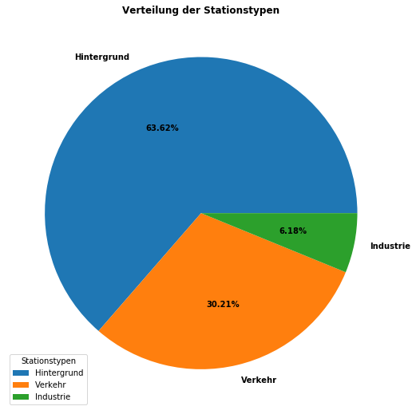

```python
# Größe des gesamten Charts ändern
plt.figure(figsize=(16, 9))

# Anzahl der jeweiligen Stationstypen herausfinden
values = stations['Name of station type'].value_counts()

# Kreisdiagramm mit formatierten (gerundeten) Labels anlegen
plt.pie(values, labels=values.index, autopct='%.2f%%', textprops=dict(fontweight='bold'))

# Legende mit Titel zu Kreisdiagramm hinzufügen
plt.legend(title="Stationstypen")

# Titel des Plots setzen
plt.title("Verteilung der Stationstypen", fontdict=dict(fontweight='bold'))

# Kreisdiagramm anzeigen
plt.show()
```

**d) Aufgabenstellung**

Erstellen Sie mit `folium` eine interaktive Karte, auf der die einzelnen Messstationen als Kreise eingezeichnet sind. Industrienahe Stationen sollen gelb, verkehrsnahe rot und die Stationen mit Hintergrundbelastung grün eingezeichnet werden. Beim Klick auf die Kreise sollen die Namen der Stationen angezeigt werden.

```python
# Neue Karte erstellen
map_germany = folium.Map(location=[51.30, 10.0], zoom_start=6, control_scale=True)

# Minimap zur besseren Übersicht erstellen
minimap = plugins.MiniMap(toggle_display=True)

# Minimap der großen Map hinzufügen
map_germany.add_child(minimap)

# Funktion zur Bestimmung der anzuzeigenden Farben
def get_color_to_type(type):
    if type == 'Hintergrund': return 'green'
    elif type == 'Industrie': return 'yellow'
    elif type == 'Verkehr': return 'red'
    else: return 'black' # Falls die Daten nicht vorhanden sind

# Marker hinzufügen und je nach 'Name of station type' unterschiedlich einfärben
stations.apply(lambda row: folium.CircleMarker(
    location=[row['Latitude of station'], row['Longitude of station']],
    popup=row['Name of station'],
    radius=8,
    color=get_color_to_type(row['Name of station type']),
    fill_color=get_color_to_type(row['Name of station type'])
).add_to(map_germany), axis=1)

# Map anzeigen
map_germany
```

Make this Notebook Trusted to load map: File -> Trust Notebook

[interactive chart not shown]

**e) Aufgabenstellung**

Erzeugen Sie durch Filterung des DataFrames `stations` einen DataFrame `stations_BY`, der die Informationen zu allen Messstationen in Bayern enthält.

```python
# Alle bayerischen Stationen durch Pr üfen des Wertes in der Spalte 'Code of Network' in neue Variable speichern
stations_BY = stations.loc[stations['Code of network'] == 'BY']

# Erzeugten neuen DataFrame mit den ersten 10 Einträgen zu Messstationen in Bayern anzeigen
stations_BY.head(35)
```

|  | Id of station | Code of station | Name of station | City of station | Synonym of station | Date of first activity | Date of last activity | Longitude of station | Latitude of station | Id of network | Id of station setting | Id of station type | Code of network | Name of network | Name of station setting | Short name of station setting | Name of station type | Street of station | Street number of station | ZIP code of station |
| --- | --- | --- | --- | --- | --- | --- | --- | --- | --- | --- | --- | --- | --- | --- | --- | --- | --- | --- | --- | --- |
| 80 | 435 | DEBY001 | Ansbach/Residenzstraße | Ansbach | NaN | 1989-07-01 | NaN | 10.5723 | 49.3049 | 2 | 1 | 3 | BY | Bayern | städtisches Gebiet | städtisch | Verkehr | Residenzstraße/Brauhausstraße | NaN | 91522 |
| 81 | 436 | DEBY002 | Arzberg/Egerstraße | Arzberg | NaN | 1980-01-01 | NaN | 12.1887 | 50.0582 | 2 | 2 | 1 | BY | Bayern | vorstädtisches Gebiet | vorstädtisch | Hintergrund | Egerstraße | 17 | 95659 |
| 82 | 438 | DEBY004 | Kleinwallstadt/Hofstetter Straße | Kleinwallstadt | NaN | 1978-08-01 | NaN | 9.1715 | 49.8694 | 2 | 6 | 1 | BY | Bayern | ländlich stadtnah | ländlich | Hintergrund | Hofstetter Straße | 13 | 63839 |
| 83 | 439 | DEBY005 | Aschaffenburg/Bussardweg | Aschaffenburg | NaN | 1978-08-01 | NaN | 9.1180 | 49.9915 | 2 | 2 | 1 | BY | Bayern | vorstädtisches Gebiet | vorstädtisch | Hintergrund | Bussardweg | ggüber 2 | 63741 |
| 84 | 440 | DEBY006 | Augsburg/Königsplatz | Augsburg | NaN | 1975-01-01 | NaN | 10.8950 | 48.3646 | 2 | 1 | 3 | BY | Bayern | städtisches Gebiet | städtisch | Verkehr | Königsplatz | NaN | 86150 |
| 85 | 441 | DEBY007 | Augsburg/Bourges-Platz | Augsburg | NaN | 1986-08-01 | NaN | 10.8884 | 48.3766 | 2 | 1 | 1 | BY | Bayern | städtisches Gebiet | städtisch | Hintergrund | Bourges-Platz | NaN | 86153 |
| 86 | 443 | DEBY009 | Bamberg/Löwenbrücke | Bamberg | NaN | 1978-01-01 | NaN | 10.8877 | 49.8983 | 2 | 1 | 1 | BY | Bayern | städtisches Gebiet | städtisch | Hintergrund | Löwenbrücke | NaN | 96047 |
| 87 | 446 | DEBY012 | Burghausen/Marktler Straße | Burghausen | NaN | 1976-01-01 | NaN | 12.8293 | 48.1772 | 2 | 2 | 1 | BY | Bayern | vorstädtisches Gebiet | vorstädtisch | Hintergrund | Klausenstraße | NaN | 84489 |
| 88 | 447 | DEBY013 | Mehring/Sportplatz | Mehring | NaN | 1977-03-01 | NaN | 12.7814 | 48.1828 | 2 | 5 | 1 | BY | Bayern | ländlich regional | ländlich | Hintergrund | Scheibelbergstraße | NaN | 84561 |
| 89 | 448 | DEBY014 | Coburg/Lossaustraße | Coburg | NaN | 1987-02-01 | NaN | 10.9593 | 50.2606 | 2 | 1 | 3 | BY | Bayern | städtisches Gebiet | städtisch | Verkehr | Lossaustraße | NaN | 96450 |
| 90 | 454 | DEBY020 | Hof/LfU | Hof | NaN | 1988-06-01 | NaN | 11.8975 | 50.3206 | 2 | 2 | 1 | BY | Bayern | vorstädtisches Gebiet | vorstädtisch | Hintergrund | Dr.-Enders-Straße | NaN | 95030 |
| 91 | 455 | DEBY021 | Ingolstadt/Rechbergstraße | Ingolstadt | NaN | 1989-06-01 | NaN | 11.4288 | 48.7694 | 2 | 1 | 3 | BY | Bayern | städtisches Gebiet | städtisch | Verkehr | Rechbergstraße | NaN | 85049 |
| 92 | 460 | DEBY026 | Vohburg a.d. Donau/Alter Wöhrer Weg | Vohburg a.d. Donau | NaN | 2015-10-22 | NaN | 11.6383 | 48.7671 | 2 | 2 | 1 | BY | Bayern | vorstädtisches Gebiet | vorstädtisch | Hintergrund | Alter Wöhrer Weg | NaN | 85088 |
| 93 | 462 | DEBY028 | Kelheim/Regensburger Straße | Kelheim | NaN | 1975-01-01 | NaN | 11.8792 | 48.9095 | 2 | 1 | 3 | BY | Bayern | städtisches Gebiet | städtisch | Verkehr | Regensburger Straße | NaN | 93309 |
| 94 | 464 | DEBY030 | Saal a.d. Donau/Regensburger Straße | Saal a.d. Donau | NaN | 1978-08-01 | NaN | 11.9488 | 48.9042 | 2 | 2 | 1 | BY | Bayern | vorstädtisches Gebiet | vorstädtisch | Hintergrund | Regensburger Straße | NaN | 93342 |
| 95 | 465 | DEBY031 | Kempten (Allgäu)/Westendstraße | Kempten (Allgäu) | NaN | 1976-01-01 | NaN | 10.3066 | 47.7251 | 2 | 2 | 1 | BY | Bayern | vorstädtisches Gebiet | vorstädtisch | Hintergrund | Westend-/Bodmanstraße | NaN | 87439 |
| 96 | 466 | DEBY032 | Kulmbach/Konrad-Adenauer-Straße | Kulmbach | NaN | 1988-10-01 | NaN | 11.4426 | 50.1031 | 2 | 1 | 1 | BY | Bayern | städtisches Gebiet | städtisch | Hintergrund | Konrad-Adenauer-Straße | NaN | 95326 |
| 97 | 467 | DEBY033 | Landshut/Podewilsstraße | Landshut | NaN | 1985-12-01 | NaN | 12.1571 | 48.5398 | 2 | 1 | 3 | BY | Bayern | städtisches Gebiet | städtisch | Verkehr | Podewilsstraße | NaN | 84028 |
| 98 | 469 | DEBY035 | Lindau (Bodensee)/Friedrichshafener Straße | Lindau (Bodensee) | NaN | 2013-12-12 | NaN | 9.6889 | 47.5575 | 2 | 1 | 3 | BY | Bayern | städtisches Gebiet | städtisch | Verkehr | Friedrichshafener Straße | NaN | 88131 |
| 99 | 471 | DEBY037 | München/Stachus | München | NaN | 1978-01-01 | NaN | 11.5649 | 48.1373 | 2 | 1 | 3 | BY | Bayern | städtisches Gebiet | städtisch | Verkehr | Sonnenstraße | NaN | 80335 |
| 100 | 473 | DEBY039 | München/Lothstraße | München | NaN | 1978-01-01 | NaN | 11.5547 | 48.1545 | 2 | 1 | 1 | BY | Bayern | städtisches Gebiet | städtisch | Hintergrund | Lothstraße | 62 | 80335 |
| 101 | 481 | DEBY047 | Naila/Selbitzer Berg | Naila | NaN | 1986-01-01 | NaN | 11.7216 | 50.3232 | 2 | 6 | 1 | BY | Bayern | ländlich stadtnah | ländlich | Hintergrund | Selbitzer Berg | NaN | 95119 |
| 102 | 483 | DEBY049 | Neustadt a.d. Donau/Eining | Neustadt a.d. Donau, Gde.teil Eining | NaN | 1977-03-01 | NaN | 11.7778 | 48.8532 | 2 | 5 | 1 | BY | Bayern | ländlich regional | ländlich | Hintergrund | KEH7 (Kreisstraße) | NaN | 93333 |
| 103 | 486 | DEBY052 | Neu-Ulm/Gabelsbergerstraße | Neu-Ulm | NaN | 1978-01-01 | NaN | 10.0083 | 48.3971 | 2 | 1 | 1 | BY | Bayern | städtisches Gebiet | städtisch | Hintergrund | Gabelsberger-/Bahnhofstraße | NaN | 89231 |
| 104 | 487 | DEBY053 | Nürnberg/Bahnhof | Nürnberg | NaN | 1986-09-01 | NaN | 11.0884 | 49.4459 | 2 | 1 | 3 | BY | Bayern | städtisches Gebiet | städtisch | Verkehr | Köhnstraße | NaN | 90478 |
| 105 | 490 | DEBY056 | Fürth/Theresienstraße | Fürth | NaN | 1990-11-01 | NaN | 10.9847 | 49.4722 | 2 | 1 | 3 | BY | Bayern | städtisches Gebiet | städtisch | Verkehr | Theresienstraße | NaN | 90762 |
| 106 | 492 | DEBY058 | Nürnberg/Muggenhof | Nürnberg, Stadtteil Muggenhof | NaN | 1978-08-01 | NaN | 11.0248 | 49.4622 | 2 | 1 | 1 | BY | Bayern | städtisches Gebiet | städtisch | Hintergrund | Fuchsstraße | 13 | 90429 |
| 107 | 496 | DEBY062 | Regen/Bodenmaiser Straße | Regen | NaN | 1989-02-01 | NaN | 13.1289 | 48.9724 | 2 | 2 | 1 | BY | Bayern | vorstädtisches Gebiet | vorstädtisch | Hintergrund | Bodenmaiser Straße | NaN | 94209 |
| 108 | 497 | DEBY063 | Regensburg/Rathaus | Regensburg | NaN | 2015-03-11 | NaN | 12.1016 | 49.0152 | 2 | 1 | 3 | BY | Bayern | städtisches Gebiet | städtisch | Verkehr | D.-Martin-Luther-Straße | NaN | 93047 |
| 109 | 501 | DEBY067 | Schwandorf/Wackersdorfer Straße | Schwandorf | NaN | 1980-01-01 | NaN | 12.1281 | 49.3220 | 2 | 2 | 1 | BY | Bayern | vorstädtisches Gebiet | vorstädtisch | Hintergrund | Wackersdorfer Straße | NaN | 92421 |
| 110 | 502 | DEBY068 | Schweinfurt/Obertor | Schweinfurt | NaN | 1976-01-01 | NaN | 10.2321 | 50.0484 | 2 | 1 | 1 | BY | Bayern | städtisches Gebiet | städtisch | Hintergrund | Kornmarkt | NaN | 97421 |
| 111 | 506 | DEBY072 | Tiefenbach/Altenschneeberg | Tiefenbach, Gde.teil Altenschneeberg | NaN | 1983-10-01 | NaN | 12.5489 | 49.4385 | 2 | 5 | 1 | BY | Bayern | ländlich regional | ländlich | Hintergrund | Flurstück-Nr. 14 | NaN | 93464 |
| 112 | 509 | DEBY075 | Weiden i.d.OPf./Nikolaistraße | Weiden i.d.OPf. | NaN | 1980-01-01 | NaN | 12.1594 | 49.6790 | 2 | 1 | 1 | BY | Bayern | städtisches Gebiet | städtisch | Hintergrund | Nikolaistraße | NaN | 92637 |
| 113 | 511 | DEBY077 | Würzburg/Kopfklinik | Würzburg | NaN | 1975-01-01 | NaN | 9.9564 | 49.8047 | 2 | 2 | 1 | BY | Bayern | vorstädtisches Gebiet | vorstädtisch | Hintergrund | Lindleinstraße | NaN | 97080 |
| 114 | 513 | DEBY079 | Bad Reichenhall/Kirchholzstraße | Bad Reichenhall,Kirchholzstraße | NaN | 2017-12-05 | NaN | 12.8912 | 47.7334 | 2 | 1 | 1 | BY | Bayern | städtisches Gebiet | städtisch | Hintergrund | Kirchholzstraße | NaN | 83435 |

## Aufgabe 2:

> *NO<sub>2</sub>-Daten, Datenvorbereitung, Datenqualitat*  
> **Zurück zur Gliederung**

**a) Aufgabenstellung**

Laden Sie über die Measurements-API für alle bayerischen Stationen (wie oben ermittelt) die Ein-Stunden-Mittelwerte für die NO<sub>2</sub>-Konzentrationen für den Zeitraum 01.01.2016 bis 31.12.2019 herunter und überführen Sie diese in einen DataFrame namens `data_no2`. Dieser soll die Spalten `STATION_ID`, `DT` und `NO2` besitzen, die die Stations-ID, das Messdatum mit Uhrzeit sowie die gemessene NO<sub>2</sub>-Konzentration enthalten.

```python
# Prüfen, ob die Daten bereits als CSV Datei vorliegen
if(path.exists('cache/data_no2.csv')):
    data_no2 = pd.read_csv('cache/data_no2.csv')
else:
    # Definiere die spezifischen URL-Parameter
    # Scope-ID: 2 = One hour average (siehe https://www.umweltbundesamt.de/api/air_data/v2/scopes/json)
    # Component-ID: 5 = Nitrogen dioxide (siehe https://www.umweltbundesamt.de/api/air_data/v2/components/json)
    payload = {'date_from': '2016-01-01', 'date_to': '2019-12-31', 'time_from': '1', 'time_to': '24', 'component': '5', 'scope': '2', 'station': ''}

    # Aus Performancegründen eine leere temporäre Liste zum Speichern der einzelnen erhaltenen Daten anlegen
    data_temp = []

    # Iterieren über alle bayerischen Stationen
    for id in stations_BY['Id of station']:

        # Station-ID für die API Abfrage aktualisieren
        payload['station'] = id

        # POST-HTTP-Request mit oben vordefinirten Parametern
        response = requests.post('https://www.umweltbundesamt.de/api/air_data/v2/measures/json', params=payload).json()

        # Zwischenspeichern der erhaltenen Daten
        data = response['data']

        # Checken, ob die zurückgelieferten Daten vorhanden sind, falls nicht mit NaN in temporäre Liste 'data_temp' speichern
        if not data:
            data_temp.append([id, 'NaN', 'NaN'])
            continue # Nächste Iteration durchführen

        # Über alle Schlüssel (Datum mit Uhrzeit) iterieren und Werte in temporäre Liste 'data_temp' speichern
        for datetime in data[id].keys():
            data_temp.append([id, datetime, data[id][datetime][2]])

    # DataFrame "data_no2" aus oben angelegter temporärer Liste 'data_temp' erstellen
    # Grund dafür, dass ich erst jetzt den DataFrame erstelle und nicht am Anfang ist die bessere Performance der .append()-Methode normaler Listen ggü. DataFrames
    data_no2 = pd.DataFrame(data_temp, columns=['STATION_ID', 'DT', 'NO2'])

    # Als CSV Datei abspeichern, sodass beim nächsten Durchlauf data_no2 um einiges schneller geladen werden kann
    data_no2.to_csv('cache/data_no2.csv', index=False)

# DataFrame ausgeben
data_no2
```

|  | STATION_ID | DT | NO2 |
| --- | --- | --- | --- |
| 0 | 435 | 2016-01-01 00:00:00 | 28.0 |
| 1 | 435 | 2016-01-01 01:00:00 | 26.0 |
| 2 | 435 | 2016-01-01 02:00:00 | 27.0 |
| 3 | 435 | 2016-01-01 03:00:00 | 30.0 |
| 4 | 435 | 2016-01-01 04:00:00 | 32.0 |
| ... | ... | ... | ... |
| 1604569 | 615 | 2019-12-31 19:00:00 | 22.0 |
| 1604570 | 615 | 2019-12-31 20:00:00 | 21.0 |
| 1604571 | 615 | 2019-12-31 21:00:00 | 29.0 |
| 1604572 | 615 | 2019-12-31 22:00:00 | 22.0 |
| 1604573 | 615 | 2019-12-31 23:00:00 | 15.0 |

1604574 rows × 3 columns

**b) Aufgabenstellung**

Setzen Sie den `dtype` der Spalte `NO2` auf `float` und wandeln Sie die Spalte `DT` in ein DateTime-Format um.

```python
# Datentyp von DT und NO2 entsprechend ändern
data_no2 = data_no2.astype({'DT' : 'datetime64', 'NO2' : 'float'})

data_no2.info() # Überprüfung, ob Datentyp richtig geändert wurde
```

```
<class 'pandas.core.frame.DataFrame'>
RangeIndex: 1604574 entries, 0 to 1604573
Data columns (total 3 columns):
 #   Column      Non-Null Count    Dtype
---  ------      --------------    -----
 0   STATION_ID  1604574 non-null  int64
 1   DT          1604568 non-null  datetime64[ns]
 2   NO2         1592259 non-null  float64
dtypes: datetime64[ns](1), float64(1), int64(1)
memory usage: 36.7 MB
```

**c) Aufgabenstellung**

Entfernen Sie alle Zeilen, bei denen der Wert in der Spalte `NO2` fehlt. Geben Sie an, wie viele Zeilen dadurch entfernt wurden.

```python
# Vorherherige Zeilenanzahl in Variable speichern, sodass der spätere Wert damit verglichen werden kann
row_count_before = data_no2.shape[0]

# Alle nicht vorhandenen Werte der Spalte "NO2" löschen
data_no2.dropna(subset=['NO2'], how='all', inplace=True)

# Neue Zeilenanzahl nach Löschen der Werte in neue Variable speichern
row_count_after = data_no2.shape[0]

# Entfernte Zeilen ausgeben
deleted_values = row_count_before - row_count_after

print('Es wurden insgesamt ' + str(deleted_values) + ' Einträge entfernt.')
```

```
Es wurden insgesamt 12315 Einträge entfernt.
```

**e) Aufgabenstellung**

Für wie viele Stationen enthält der DataFrame `data_no2` nun noch Daten?

```python
# Die einzigartigen Einträge entsprechen der Anzahl der noch vorhandenen Stationen
remaining_stations = data_no2['STATION_ID'].unique()

print('Es sind insgesamt noch für ' + str(remaining_stations.size) + ' Stationen Daten vorhanden.')
```

```
Es sind insgesamt noch für 47 Stationen Daten vorhanden.
```

**f) Aufgabenstellung**

Zu welchen der bayerischen Stationen enthält er keine Daten (mehr)? Geben Sie deren IDs und Namen aus.

```python
data = [] # Temporäre Liste anlegen, worin später die gelöschten Stationen eingetragen werden

# Über ALLE bayerischen Stationen iterieren (= Alle Stationen, also auch die vorhin entfernten sind in dieser Liste enthalten)
for id in stations_BY['Id of station']:
    # Prüfen, ob die ID in der "geschrumpften" Liste (ohne die gelöschten Stationen) enthalten ist, falls ja -> gelöschte Station gefunden
    if id not in remaining_stations:
        data.append([id, stations_BY.loc[stations_BY['Id of station'] == id]['Name of station'].values[0]]) # "ID" = aktuelle Iterations-ID und "Name" = Name an der Stelle der ID der jeweiligen bayerischen Station

pd.DataFrame(data, columns=['Id of station', 'Name of station']) # DataFrame aus temporärer Liste der gelöschten bayerischen Stationen erstellen und ausgeben
```

|  | Id of station | Name of station |
| --- | --- | --- |
| 0 | 436 | Arzberg/Egerstraße |
| 1 | 448 | Coburg/Lossaustraße |
| 2 | 460 | Vohburg a.d. Donau/Alter Wöhrer Weg |
| 3 | 481 | Naila/Selbitzer Berg |
| 4 | 490 | Fürth/Theresienstraße |
| 5 | 496 | Regen/Bodenmaiser Straße |
| 6 | 527 | Sulzbach-Rosenberg/Lohe |

## Aufgabe 3:

> *Explorative Datenanalyse*  
> **Zurück zur Gliederung**

**a) Aufgabenstellung**

Welches ist der in den Jahren 2016-2019 höchste gemessene Ein-Stunden-Mittelwert für NO<sub>2</sub>? Wann und an welcher Station wurde er gemessen?

```python
# Im DataFrame data_no2 in der Spalte "NO2" den höchsten Wert ermitteln und den dazugehörigen Zeilenindex abfragen
result = data_no2.loc[data_no2['NO2'].idxmax()]

print('Der höchste gemessene Ein-Stunden-Mittelwert für NO2 in Bayern in den Jahren 2016-2019 wurde ' +
     'am ' + result['DT'].strftime("%d.%m.%Y") + ', um ' + result['DT'].strftime("%H:%M:%S") + ' Uhr ' +
     'an der Station "' + str(stations_BY.loc[stations_BY['Id of station'] == result['STATION_ID']]['Name of station'].values[0]) +
     '" (ID: ' + str(result['STATION_ID']) + ') ' +
     'mit dem Wert ' + str(result['NO2']) + ' µg/m^3' + ' gemessen.')
```

```
Der höchste gemessene Ein-Stunden-Mittelwert für NO2 in Bayern in den Jahren 2016-2019 wurde am 22.06.2017, um 16:00:00 Uhr an der Station "München/Landshuter Allee" (ID: 535) mit dem Wert 270.0 µg/m^3 gemessen.
```

**b) Aufgabenstellung**

An welchem Tag im Auswertezeitraum war die durchschnittliche NO<sub>2</sub>-Konzentration über alle bayerischen Stationen am höchsten und welchen Wert hatte sie?

```python
# Einen "neuen" DataFrame mit dem Datum als Index und dem dazugehörigen Durchschnitts-NO2 Wert des jeweiligen Tages als Value er Spalte "NO2"
temp_data_no2 = data_no2.copy()
avg_daily_no2 = temp_data_no2.set_index('DT').groupby(pd.Grouper(freq='D')).mean() # pd.Grouper nutzt das DateTime-Format und gruppiert nach dem Datum ('D'). Alternativ kann man auch nach ('T') für Time gruppieren.

# Im DataFrame avg_daily_no2 in der Spalte "NO2" den höchsten Wert ermitteln und den dazugehörigen Zeilenindex abfragen
result = avg_daily_no2.loc[avg_daily_no2['NO2'].idxmax()]

print('Der Wert war mit ' + str(round(result['NO2'], 2)) + ' µg/m^3 am '
      + avg_daily_no2.iloc[result].index[0].strftime('%d.%m.%Y') + ' am höchsten.')
```

[output not shown]

**c) Aufgabenstellung**

Ermitteln Sie die 10 höchsten Messwerte und die zugehörigen Messzeitpunkte für die Station in der Nikolaistraße in Weiden.

```python
# ID der Weidener Station erhalten
station_weiden_id = stations_BY.loc[stations_BY['City of station'] == 'Weiden i.d.OPf.']['Id of station'].values[0]

# Werte der Weidener Station absteigend nach NO2 sortieren und ausgeben
data_no2.loc[data_no2.STATION_ID==station_weiden_id, 'DT':'NO2'].sort_values(by="NO2", ascending=False).head(10)
```

|  | DT | NO2 |
| --- | --- | --- |
| 921406 | 2017-01-23 17:00:00 | 103.0 |
| 921360 | 2017-01-21 19:00:00 | 102.0 |
| 936574 | 2018-10-17 17:00:00 | 100.0 |
| 921407 | 2017-01-23 18:00:00 | 100.0 |
| 921408 | 2017-01-23 19:00:00 | 98.0 |
| 921359 | 2017-01-21 18:00:00 | 97.0 |
| 921409 | 2017-01-23 20:00:00 | 97.0 |
| 921984 | 2017-02-16 19:00:00 | 97.0 |
| 939767 | 2019-02-27 18:00:00 | 96.0 |
| 921983 | 2017-02-16 18:00:00 | 96.0 |

**d) Aufgabenstellung**

Berechnen Sie die Mittelwerte der gemessenen NO<sub>2</sub>-Konzentrationen über die einzelnen Jahre. Wie haben sich diese zeitlich entwickelt? Unterscheiden Sie dabei auch nach dem Stations-Typ.

```python
temp_data_no2 = data_no2.copy()

# 'Name of station type' (Messstationstyp) als neue Spalte zur dazugehörigen Stations-Id hinzufügen
temp_data_no2 = data_no2.merge(stations_BY[['Id of station', 'Name of station type']], left_on='STATION_ID', right_on='Id of station')

# DT als Index setzen, sodass danach gruppiert werden kann
temp_data_no2 = temp_data_no2.set_index('DT')

# Nicht mehr benötigte Spalten löschen
temp_data_no2.drop(columns=['Id of station', 'STATION_ID'], inplace=True)

# Nach Jahr und Stationstyp gruppieren und den jeweiligen Mittelwert berechnen
temp_data_no2 = temp_data_no2.groupby(['Name of station type', pd.Grouper(freq='Y')]).mean()

# Ergebnis ausgeben
temp_data_no2
```

| Name of station type | DT | NO2 |
| --- | --- | --- |
| Hintergrund | 2016-12-31 | 19.640390 |
|  | 2017-12-31 | 19.951054 |
|  | 2018-12-31 | 18.615261 |
|  | 2019-12-31 | 17.505476 |
| Verkehr | 2016-12-31 | 38.385236 |
|  | 2017-12-31 | 36.924944 |
|  | 2018-12-31 | 34.579768 |
|  | 2019-12-31 | 31.689138 |

### Auswertung der Aufgabe 3d)

Anhand der jährlichen Durchschnittsdaten der NO2-Messwerte lässt sich erkennen, dass die Werte sowohl in den Verkehrs-, als auch in den Hintergrundbereichen von Jahr zu Jahr tendenziell gesunken sind.

## Aufgabe 4:

> *Verletzung der zulässigen NO<sub>2</sub>-Grenzwerte*  
> **Zurück zur Gliederung**

**a) Aufgabenstellung**

Ermitteln Sie, an welchen bayerischen Stationen jeweils in den Jahren 2016-2019 Überschreitungen des Stundengrenzwerts (d.h. der Ein-Stunden-Mittelwert überschreitet 200 µg/m<sup>3</sup>) gemessen wurden, und geben Sie an wie viele Überschreitungen es jeweils waren. Dieser darf innerhalb eines Jahres höchstens 18-Mal pro Station überschritten werden. Welche Stationen haben dieses Kriterium verletzt?

```python
temp_data_no2 = data_no2.copy()

# Alle Stationen erhalten, die einen NO2-Wert > 200 haben, nach Stations-ID gruppieren, die Anzahl der Einträge zählen und absteigend sortieren
result = temp_data_no2.loc[data_no2['NO2'] > 200].groupby('STATION_ID').count().sort_values(by="NO2", ascending=False)

def get_name_to_station_id(id):
    return stations_BY.loc[stations_BY['Id of station'] == id]['Name of station'].values[0]

# Überschreitungen mit dazugehöriger Stations-ID ausgeben
for id in result.index:
    print('Die Station "' + str(get_name_to_station_id(id)) + '" hat den Grenzwert insgesamt ' + str(result.loc[result.index == id]['NO2'].values[0]) + 'x überschritten.')

# Welche Station hat den Grenzwert innerhalb eines Jahres mehr als 18-Mal überschritten?
station = result.loc[result['NO2'] > 18]

print('\nÜberschreitung des Grenzwertes über 18x: Die Station "' + str(get_name_to_station_id(station.index.values[0])) + '" hat den Grenzwert insgesamt ' + str(station['NO2'].values[0]) + 'x überschritten.')
```

```
Die Station "München/Landshuter Allee" hat den Grenzwert insgesamt 27x überschritten.
Die Station "Augsburg/Karlstraße" hat den Grenzwert insgesamt 2x überschritten.
Die Station "München/Lothstraße" hat den Grenzwert insgesamt 1x überschritten.
Die Station "Würzburg/Stadtring Süd" hat den Grenzwert insgesamt 1x überschritten.

Überschreitung des Grenzwertes über 18x: Die Station "München/Landshuter Allee" hat den Grenzwert insgesamt 27x überschritten.
```

**b) Aufgabenstellung**

Ermitteln Sie, an welchen bayerischen Stationen und in welchen Jahren der Jahresmittelwert der Ein-Stunden-Mittelwerte die Grenze von 40µg/m<sup>3</sup> überschritten hat und geben Sie die zugehörigen Jahresmittelwerte an.

```python
temp_data_no2 = data_no2.copy()

# Index auf "DateTime" (DT) setzen, sodass danach gruppiert werden kann
temp_data_no2 = temp_data_no2.set_index('DT')

# Nach den einzelnen Stationen & den jeweiligen Jahren gruppieren und die dazugehörigen Jahresmittelwerte berechnen
temp_data_no2 = temp_data_no2.groupby(['STATION_ID', pd.Grouper(freq='Y')]).mean()

# Alle Jahresdurchschnittswerte der einzelnen Stationen prüfen, ob Mittelwert > 40 ist
temp_data_no2.loc[temp_data_no2['NO2'] > 40]
```

| STATION_ID | DT | NO2 |
| --- | --- | --- |
| 471 | 2016-12-31 | 56.341431 |
|  | 2017-12-31 | 53.337065 |
|  | 2018-12-31 | 47.547575 |
|  | 2019-12-31 | 42.172516 |
| 497 | 2016-12-31 | 41.710766 |
|  | 2017-12-31 | 41.483579 |
| 530 | 2016-12-31 | 45.973654 |
|  | 2017-12-31 | 44.028604 |
|  | 2018-12-31 | 43.056357 |
| 535 | 2016-12-31 | 79.883219 |
|  | 2017-12-31 | 78.085584 |
|  | 2018-12-31 | 66.196090 |
|  | 2019-12-31 | 62.741190 |
| 539 | 2016-12-31 | 41.858642 |
| 540 | 2016-12-31 | 46.259578 |
|  | 2017-12-31 | 42.590732 |
|  | 2018-12-31 | 46.410048 |

## Aufgabe 5:

> *Visualisierung*  
> **Zurück zur Gliederung**

**a) Aufgabenstellung**

Erstellen Sie ein Histogramm über alle gemessenen NO<sub>2</sub>-Konzentrationen im Auswertungszeitraum 2016-2019.

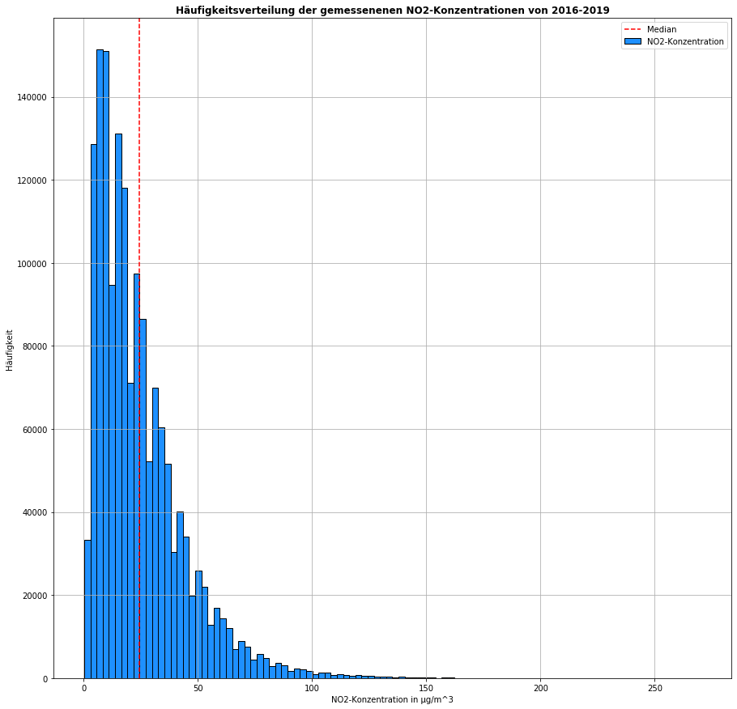

```python
plt.figure(figsize=(15, 15))

temp_data_no2 = data_no2.copy()

# Anzahl der jeweiligen Stationstypen herausfinden
values = temp_data_no2['NO2']

# Histogramm anlegen - der zweite Parameter (100) entspricht den Unterteilungen
plt.hist(values, 100, edgecolor='black', label='NO2-Konzentration', color='dodgerblue')

# Vertikale Linie des Wertes des Medians einzeichnen
plt.axvline(float(values.mean()), color='red', label='Median', linewidth='1.5', linestyle='dashed')

plt.legend()
plt.title('Häufigkeitsverteilung der gemessenenen NO2-Konzentrationen von 2016-2019', fontdict=dict(fontweight='bold'))

# Achsenbeschriftung hinzufügen
plt.xlabel('NO2-Konzentration in µg/m^3')
plt.ylabel('Häufigkeit')

# Grid zur besseren Übersicht hinzufügen
plt.grid(True)

plt.show()
```

**b) Aufgabenstellung**

Stellen Sie den jahreszeitlichen Verlauf der gemessenen NO<sub>2</sub>-Konzentrationen in einem geeigneten Diagramm dar. Was ist zu beobachten und wie kann dies erklärt werden?

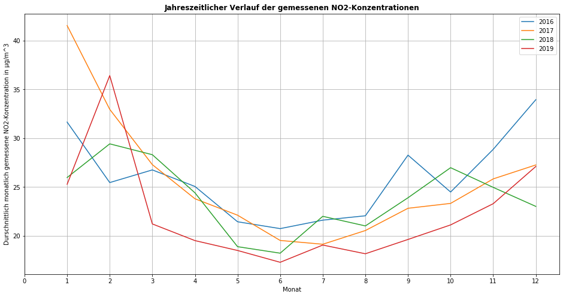

```python
plt.figure(figsize=(16, 8))

# Zwei neue "temporäre" Spalten anlegen, sodass die Jahre und Monate der dazugehörigen Station leichter abgefragt werden können
temp_data_no2['year'] = temp_data_no2['DT'].dt.year
temp_data_no2['month'] = temp_data_no2['DT'].dt.month

# DataFrame nach Jahr und Monat gruppieren, den dazugehörigen Mittelwert der NO2-Konzentration berechnen
# unstack() bewirkt, dass die Mittelwerte der Jahre mit den dazugehörigen Monaten in ein übersichtlichen DataFrame umgewandelt werden
# Anschließend wird der von unstack() zurückgelieferte DataFrame nach Monaten sortiert
values = temp_data_no2.groupby(['month', 'year']).mean()['NO2'].unstack().sort_values(ascending=True, by='month')

# Liniendiagramm anlegen
plt.plot(values)

# Legende mit Jahreswerten hinzufügen
plt.legend(('2016', '2017', '2018', '2019'))

plt.title('Jahreszeitlicher Verlauf der gemessenen NO2-Konzentrationen', fontdict=dict(fontweight='bold'))

plt.xlabel('Monat')
plt.ylabel('Durschnittlich monatlich gemessene NO2-Konzentration in µg/m^3')

# x-Achsenwerte mit Schrittweite 1 hinzufügen (Darstellung der Monate)
plt.xticks(np.arange(0, 13, step=1))

plt.grid(True)

plt.show()
```

### Auswertung der Aufgabe 5b)

Der jahreszeitliche Verlauf zeigt, dass die NO2-Konzentration in den Sommermonaten sinkt und zu den Wintermonaten wieder steigt. Es ist bekanntlich so, dass kalte Luft am Boden bleibt, somit bleibt auch NO2 bei kalten Temperaturen eher im bodennahen Bereich. In den warmen Sommermonaten hingegen steigen die Luftmassen nach oben. Dadurch kann sich das NO2 viel besser verteilen und sich mit sauberer Luft vermischen, sodass folglich die NO2-Werte sinken.

**c) Aufgabenstellung**

Visualisieren Sie in einem geeigneten Diagramm den Zeitverlauf der Tagesmittel der gemessenen NO<sub>2</sub>-Konzentrationen im Beobachtungszeitraum. Lassen sich Trends erkennen?

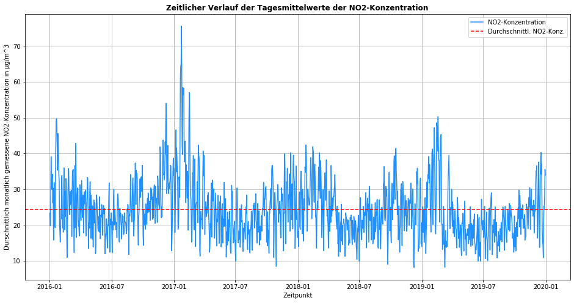

```python
plt.figure(figsize=(16, 8))

# DT als Index festlegen, sodass mit pd.Grouper nach dem angegebenen Parameter (hier 'D' = 'Day') gruppiert werden kann
# Davon wird der Mittelwert der Spalte 'NO2' berechnet
values = temp_data_no2.set_index('DT').groupby(pd.Grouper(freq='D')).mean()['NO2']

plt.plot(values, label='NO2-Konzentration', color='dodgerblue')

plt.axhline(float(values.mean()), color='red', label='Durchschnittl. NO2-Konz.', linewidth='1.5', linestyle='dashed')

plt.legend()

plt.title('Zeitlicher Verlauf der Tagesmittelwerte der NO2-Konzentration', fontdict=dict(fontweight='bold'))

plt.xlabel('Zeitpunkt')
plt.ylabel('Durschnittlich monatlich gemessene NO2-Konzentration in µg/m^3')

plt.grid()

plt.show()
```

### Auswertung der Aufgabe 5c)

Die gemessenen NO2-Tagesmittelwerte fallen in den kälteren Monaten des Jahres tendentiell höher aus als es in den Sommermonaten der Fall ist. Zudem lässt sich leicht erkennen, dass die Werte an den Werktagen steigen und zum Wochenende hin fallen.

## Aufgabe 6:

> *Interaktives Diagramm*  
> **Zurück zur Gliederung**

**a) Aufgabenstellung**

Erzeugen Sie ein interaktives Säulendiagramm in `Plotly`, in welchem die Mittelwerte der NO2-Konzentrationen im Tagesverlauf über die (vollen) Stunden aufgetragen werden. Verwenden Sie als Datengrundlage die Messwerte der bayerischen Stationen aus dem DataFrame `no2_data`. Das Diagramm soll zwei Radio-Buttons enthalten. Über den ersten RadioButton kann der Stations-Typ geﬁltert werden (Auswahlmöglichkeiten `all`, `background` und `traffic`), über den zweiten Radio-Button kann der Wochentag eingeschränkt werden (Auswahlmöglichkeiten `All`, `Monday`, ..., `Sunday`).

```python
temp_data_no2 = data_no2.copy()

# 'Name of station type' (Messstationstyp) als neue Spalte zur dazugehörigen Stations-Id hinzufügen
temp_data_no2 = data_no2.merge(stations_BY[['Id of station', 'Name of station type']], left_on='STATION_ID', right_on='Id of station')

# Nicht mehr benötigte Spalten löschen
temp_data_no2.drop(columns=['Id of station', 'STATION_ID'], inplace=True)

# Hinzufügen zwei neuer Spalten 'DAY_OF_WEEK' und 'HOUR', sodass danach gruppiert werden kann
temp_data_no2['DAY_OF_WEEK'] = temp_data_no2['DT'].dt.dayofweek
temp_data_no2['HOUR'] = temp_data_no2['DT'].dt.hour

# Anlegen einer leeren Liste für die x-Achsen-Werte
x_values = []

# x-Achsen-Werte zu Liste 'x_values' hinzufügen
for i in range(0, 24): # Über alle Stunden iterieren
    # Zeitspanne der vollen Stunden zur Liste hinzufügen
    x_values.append(str(i) + ' bis ' + str(i + 1) + ' Uhr')

# Stationstyp, Wochentag und Stunde zusammen gruppieren und daraus stündliche NO2-Mittelwerte berechnen
hourly_avg = temp_data_no2.groupby(['Name of station type', 'DAY_OF_WEEK', 'HOUR'], as_index=False)['NO2'].mean()

# Aktualisieren der y-Werte des Bar-Charts abhängig von den ausgewählten Radio-Buttons
def y_values():
    temp_type = type_radio.value # Aktuell ausgewählter Stations-Typ
    temp_weekday = weekday_radio.value # Aktuell ausgewählter Wochentag

    # Ausgewählter Stations-Typ
    if temp_type == 'Alle':
        # Stations-Typ außen vor lassen und nur nach Wochentag und Stunde gruppieren
        temp_values = hourly_avg.groupby(['DAY_OF_WEEK', 'HOUR'], as_index=False)

        # NO2-Mittelwerte berechnen
        temp_values = temp_values['NO2'].mean()
        #print(temp_values)
    else:
        # Nach dem ausgewähltem Station-Typ filtern
        temp_values = hourly_avg.loc[hourly_avg['Name of station type'] == temp_type]
        #print(temp_values)

    # Ausgewählter Wochentag
    if temp_weekday == 'Alle':
        # Wochentag außen vor lassen und nur nach den Stunden gruppieren
        temp_values = temp_values.groupby(['HOUR'], as_index=False)

        # NO2-Mittelwerte berechnen
        temp_values = temp_values['NO2'].mean()
        #print(temp_values)
    else:
        # Nach ausgewähltem Wochentag filtern, sodass in der Spalte 'DAY_OF_WEEK' nur noch der numerische Wert des Wochentags steht (bei Montag z.B. "0")
        temp_values = temp_values.loc[temp_values['DAY_OF_WEEK'] == weekdays.index(temp_weekday) - 1]
        #print(temp_values)

    # Spalte NO2 als y-Werte zurückliefern
    return temp_values['NO2']

# Erstellen der Radio-Buttons für den Stations-Typ
# Kleine Abweichung von Aufgabenstellung: Deutsche Benennung, da die obige API-Abfrage mit 'lang=de' ausgeführt wurde
type_radio = widgets.RadioButtons(options=['Alle',
                                            'Hintergrund',
                                            'Verkehr'
                                           ], description='Stations-Typ')

# Extra Liste der Wochentage erstellen, da in den Methode 'y_values' darauf zugegriffen werden muss
weekdays = ['Alle', 'Montag', 'Dienstag', 'Mittwoch', 'Donnerstag', 'Freitag', 'Samstag', 'Sonntag']
# Erstellen des Radio-Buttons für die Wochentage
weekday_radio = widgets.RadioButtons(options=weekdays, description='Wochentag')

# "Event" wird ausgelöst, sobald ein Radio-Button der Gruppe 'Stations-Typ' ausgewählt wurde
def on_click_type(change):
    fig.data[0].y = y_values()

# "Event" wird ausgelöst, sobald ein Radio-Button der Gruppe 'Wochentag' ausgewählt wurde
def on_click_weekday(change):
    fig.data[0].y = y_values()

# 'on_click_type' als Handler registrieren, der aufgerufen wird, sobald sich der Radio-Button 'types_radio' ändert
type_radio.observe(on_click_type)
# 'on_click_weekday' als Handler registrieren, der aufgerufen wird, sobald sich der Radio-Button 'weekday_radio' ändert
weekday_radio.observe(on_click_weekday)

# Zeichnen des Bar-Charts
fig = go.FigureWidget()

# Hinzufügen der Säulen
fig.add_trace(go.Bar(x=x_values, y=y_values(), text=y_values()))

# Hinzufügen des Wertes zur Säule und Ändern der Säulenfarbe
fig.update_traces(marker_color='dodgerblue')

# 45 Grad Winkel + etwas größerer Säulenabstand zur besseren Lesbarkeit
fig.update_layout(xaxis_tickangle=45, bargap=0.20)

# Titel + X-/Y-Achsenbeschriftung setzen
fig.update_layout(title_text='Mittelwerte der NO2-Konzentrationen im Tagesverlauf über die vollen Stunden')
fig.update_layout(
    xaxis=dict(
        title='Tagesverlauf in vollen Stunden',
        titlefont_size=14,
        tickfont_size=12,
    ),
    yaxis=dict(
        title='NO2-Konzentration in µg/m^3',
        titlefont_size=14,
        tickfont_size=12,
        range=[0, 55]
    ))

# Zusammenfügen des Bar-Charts mit den Radio-Buttons zu einer vertikal angeordneten Box
w_box = widgets.VBox([fig, widgets.Box([type_radio, weekday_radio])])

# Bar-Chart inklusive Radio-Buttons anzeigen
w_box
```

[output not shown]

**b) Aufgabenstellung**

Analysieren Sie anhand des erstellten Diagramms den tageszeitlichen Verlauf der NO<sub>2</sub>-Konzentration in Abhängigkeit des Stations-Typs und des Wochentags. Beschreiben und interpretieren Sie die beobachteten Zusammenhänge.

### Auswertung der Aufgabe 6a)

Bei der Analyse des Säulendiagramms lässt sich grundsätzlich festhalten, dass die NO2-Belastung unter der Woche tendenziell höher ausfällt als am Wochenende. Dieser Aspekt lässt sich darauf zurückführen, dass an Werktagen der Berufsverkehr zusätzlich zum normalen Alltagsverkehr hinzukommt.

Sobald man zwischen den beiden Stations-Typen "Hintergrund" und "Verkehr" unterscheidet fällt auf, dass die NO2-Konzentration bei verkehrsnahen Stationen deutlich höher als bei Messstationen im Hintergrund ist.

Betrachtet man dazu den Tagesverlauf unter der Woche wird deutlich, dass zu den Stoßzeiten des Berufsverkehrs, also von 5-10 Uhr vormittags und von 16-20 Uhr abends, die NO2-Werte ihre Höhepunkte erreichen.

Ohne Unterscheidung des Stations-Typ fällt am Wochenende auf, dass der Berufsverkehr in der früh nahezu wegfällt, allerdings steigen die Werte gegen Abend wieder an. Das kann daran liegen, da einige Berufstätige über das Wochenende daheim sind und Sonntag Abend wieder zu ihrer Zweitwohnung nahe der Arbeit fahren.

## Aufgabe 7:

> *Abhängigkeit zwischen der Ozonkonzentration und der Temperatur*  
> **Zurück zur Gliederung**

**a) Aufgabenstellung**

Laden Sie sich die Wetterdaten aus der Datei `wetterdaten.csv` in einen DataFrame namens `df_weather`. Dieser enthält historische Wetterdaten für die Oberpfalz für die Jahre 2016-2019. Für unsere Analyse ist die Spalte `temperatureMax` relevant, die die Tageshöchsttemperaturen in Grad Fahrenheit beinhaltet.

```python
# CSV Datei lesen und in neuen DataFrame 'df_weather' speichern
df_weather = pd.read_csv("wetterdaten.csv")
df_weather.drop(['icon', 'precipType'], axis=1, inplace=True)

# DataFrame ausgeben
df_weather
```

|  | date | temperatureMax |
| --- | --- | --- |
| 0 | 2016-01-01 | 34.30 |
| 1 | 2016-01-02 | 33.07 |
| 2 | 2016-01-03 | 32.26 |
| 3 | 2016-01-04 | 34.04 |
| 4 | 2016-01-05 | 37.36 |
| ... | ... | ... |
| 1456 | 2019-12-27 | 40.38 |
| 1457 | 2019-12-28 | 35.71 |
| 1458 | 2019-12-29 | 32.38 |
| 1459 | 2019-12-30 | 35.56 |
| 1460 | 2019-12-31 | 38.03 |

1461 rows × 2 columns

**b) Aufgabenstellung**

Wandeln Sie die Temperaturwerte in Grad Celsius um.

```python
# Formel zur Umrechnung von Grad Fahrenheit in Grad Celsius:
# https://www.mathe-lexikon.at/grundlagen/masseinheit/temperatur/grad-fahrenheit/umrechnung-in-grad-celsius.html

# Angewendet auf die Spalte 'temperatureMax' mit Hilfe einer lambda-Funktion
df_weather['temperatureMax'] = df_weather['temperatureMax'].apply(lambda tempF: round((tempF - 32) / 1.8, 2))

# DataFrame ausgeben
df_weather
```

|  | date | temperatureMax |
| --- | --- | --- |
| 0 | 2016-01-01 | 1.28 |
| 1 | 2016-01-02 | 0.59 |
| 2 | 2016-01-03 | 0.14 |
| 3 | 2016-01-04 | 1.13 |
| 4 | 2016-01-05 | 2.98 |
| ... | ... | ... |
| 1456 | 2019-12-27 | 4.66 |
| 1457 | 2019-12-28 | 2.06 |
| 1458 | 2019-12-29 | 0.21 |
| 1459 | 2019-12-30 | 1.98 |
| 1460 | 2019-12-31 | 3.35 |

1461 rows × 2 columns

**c) Aufgabenstellung**

Laden Sie über die Measurements-API für die Station in der Nikolaistraße in Weiden die Ein-Stunden-Mittelwerte für die Ozon-Konzentrationen für den Zeitraum 01.01.2016 bis 31.12.2019 herunter und überführen Sie diese in einen DataFrame namens `data_o3`. Dieser soll die Spalten `DT` und `O3` besitzen, die das Messdatum mit Uhrzeit (Beginn der Stunde, über die gemittelt wird) und die gemessene O<sub>3</sub>-Konzentration enthalten.

```python
if(path.exists('cache/data_o3.csv')):
    data_o3 = pd.read_csv('cache/data_o3.csv')
else:
    # Weidener Stations-ID festlegen
    station_id = "509"

    # Definiere die spezifischen URL-Parameter
    # Scope-ID: 2 = One hour average (s. https://www.umweltbundesamt.de/api/air_data/v2/scopes/json)
    # Component-ID: 3 = Ozone (s. https://www.umweltbundesamt.de/api/air_data/v2/components/json)
    payload = {'date_from': '2016-01-01', 'date_to': '2019-12-31', 'time_from': '1', 'time_to': '24', 'component': '3', 'scope': '2', 'station': station_id}

    # Leere temporäre Liste zum Speichern der erhaltenen Daten anlegen
    data_temp_o3 = []

    # POST-HTTP-Request mit oben vordefinirten Parametern
    response = requests.post('https://www.umweltbundesamt.de/api/air_data/v2/measures/json', params=payload).json()
    data = response['data']

    # Über alle Schlüssel (Datum mit Uhrzeit) iterieren und Werte in temporäre Liste 'data_temp_o3' speichern
    for datetime in data[station_id].keys():
        data_temp_o3.append([datetime, data[station_id][datetime][2]])

    # DataFrame aus erhaltenen Daten erstellen
    data_o3 = pd.DataFrame(data_temp_o3, columns=['DT', 'O3'])

    # Speichern des DataFrames als .csv-Datei
    data_o3.to_csv('cache/data_o3.csv', index=False)

# DataFrame ausgeben
data_o3
```

|  | DT | O3 |
| --- | --- | --- |
| 0 | 2016-01-01 00:00:00 | 5.0 |
| 1 | 2016-01-01 01:00:00 | 6.0 |
| 2 | 2016-01-01 02:00:00 | 6.0 |
| 3 | 2016-01-01 03:00:00 | 5.0 |
| 4 | 2016-01-01 04:00:00 | 5.0 |
| ... | ... | ... |
| 35059 | 2019-12-31 19:00:00 | 0.5 |
| 35060 | 2019-12-31 20:00:00 | 0.5 |
| 35061 | 2019-12-31 21:00:00 | 0.5 |
| 35062 | 2019-12-31 22:00:00 | 0.5 |
| 35063 | 2019-12-31 23:00:00 | 0.5 |

35064 rows × 2 columns

```python
# Datentyp von DT und O3 entsprechend ändern
data_o3 = data_o3.astype({'DT' : 'datetime64', 'O3' : 'float'})

data_o3.info() # Überprüfung, ob Datentyp richtig geändert wurde
```

```
<class 'pandas.core.frame.DataFrame'>
RangeIndex: 35064 entries, 0 to 35063
Data columns (total 2 columns):
 #   Column  Non-Null Count  Dtype
---  ------  --------------  -----
 0   DT      35064 non-null  datetime64[ns]
 1   O3      35023 non-null  float64
dtypes: datetime64[ns](1), float64(1)
memory usage: 548.0 KB
```

**d) Aufgabenstellung**

Aggregieren Sie die Messwerte, indem Sie die O<sub>3</sub>-Maximalkonzentrationen pro Tag ermitteln und diese in einen DataFrame namens `o3_data_max` speichern.

```python
# Temporären DataFrame des ursprünglichen DataFrame 'data_o3' anlegen
temp_data_o3 = data_o3.copy()

# Indizierung auf DT ändern, sodass danach mittels pd.Grouper gruppiert werden kann
# Werte der noch vorhandenen Spalte 'O3' nach den Maximalwerten aggregieren
o3_data_max = temp_data_o3.set_index('DT').groupby(pd.Grouper(freq='D')).agg(['max'])

# Neuen DataFrame 'o3_data_max' mit den enthaltenen Maximalwerten ausgeben
o3_data_max
```

| DT | O3 max |
| --- | --- |
| 2016-01-01 | 40.0 |
| 2016-01-02 | 45.0 |
| 2016-01-03 | 34.0 |
| 2016-01-04 | 33.0 |
| 2016-01-05 | 19.0 |
| ... | ... |
| 2019-12-27 | 48.0 |
| 2019-12-28 | 47.0 |
| 2019-12-29 | 42.0 |
| 2019-12-30 | 30.0 |
| 2019-12-31 | 9.0 |

1461 rows × 1 columns

**e) Aufgabenstellung**

Stellen Sie den zeitlichen Verlauf der aggregierten Tageswerte für die Jahre 2016-2019 grafisch dar und beschreiben Sie die beobachteten Trends.

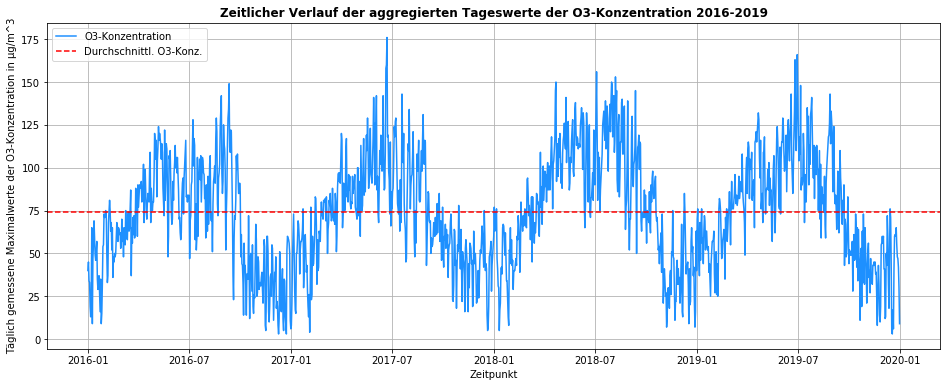

```python
plt.figure(figsize=(16, 6))

plot = plt.plot(o3_data_max, label='O3-Konzentration', color='dodgerblue')

plt.axhline(float(o3_data_max.mean()), color='red', label='Durchschnittl. O3-Konz.', linewidth='1.5', linestyle='dashed')

plt.legend()

plt.title('Zeitlicher Verlauf der aggregierten Tageswerte der O3-Konzentration 2016-2019', fontdict=dict(fontweight='bold'))

plt.xlabel('Zeitpunkt')
plt.ylabel('Täglich gemessene Maximalwerte der O3-Konzentration in µg/m^3')

plt.grid()

plt.show()
```

### Auswertung der Aufgabe 7e)

Anhand dieser Grafik lässt sich gut erkennen, dass die O3-Konzentration in den Wintermonaten ihren Tiefpunkt und in den Sommermonaten zwischen Juni und September ihren Höchstpunkt erreicht. Dieser Trend steht mit den warmen Sommertagen in Verbindung. Die warme Luft sorgt dafür, dass sich mit Hilfe des UV-Lichts der Sonne leichter aus NO2 (welches zum Großteil aus Autoabgase stammt) ein Sauerstoffatom freisetzt, welches anschließend mit einem Sauerstoffmolekül reagiert und Ozon entstehen lässt.

**f) Aufgabenstellung**

Erstellen Sie ein Streudiagramm, in dem die Maximalkonzentration (y-Achse) und die Maximaltemperatur (x-Achse) der einzelnen Tage für die Jahre 2016-2019 gegeneinander aufgetragen sind. Beschreiben und erklären Sie den beobachteten Zusammenhang.

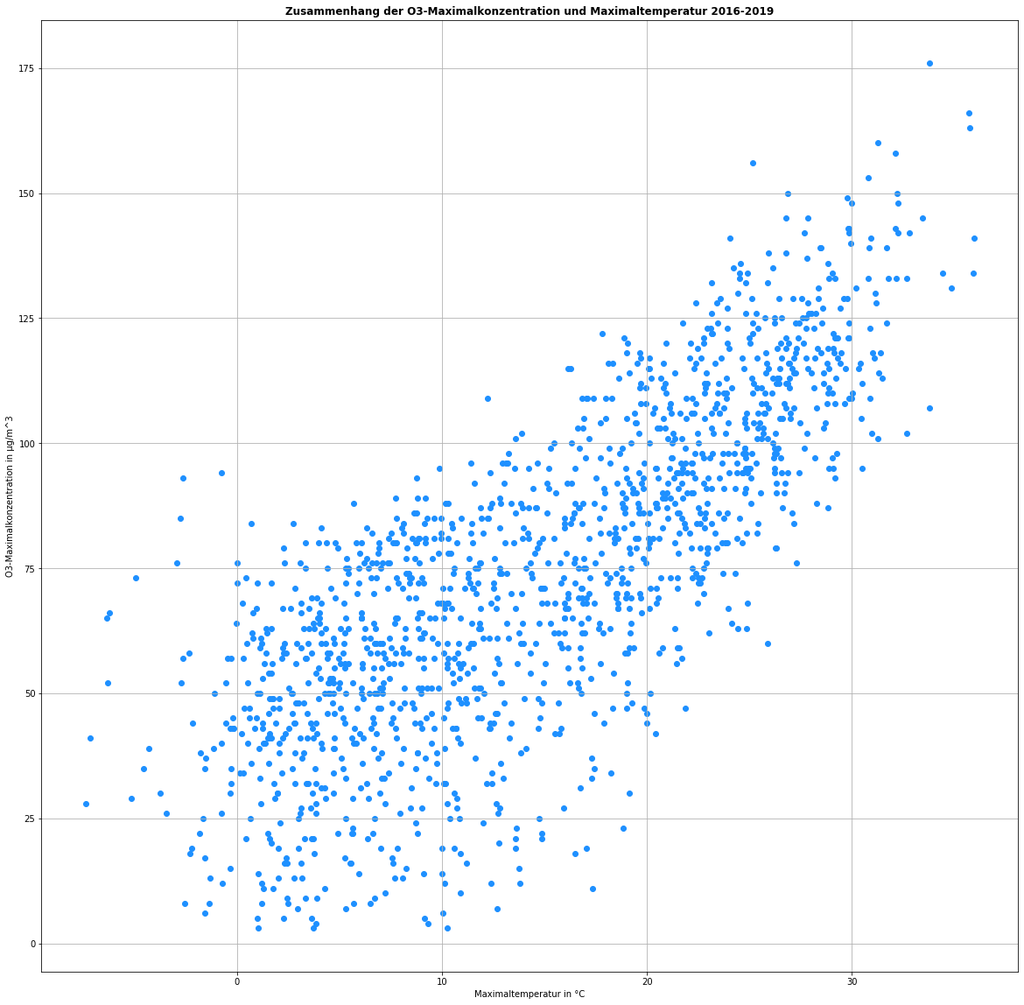

```python
plt.figure(figsize=(20, 20))

# X- & Y-Werte abfragen (X = list_temp_max, Y = list_o3_max)
list_temp_max = df_weather['temperatureMax'].tolist()
list_o3_max = o3_data_max['O3']['max'].tolist()

# Scatterplot anlegen
plt.scatter(list_temp_max, list_o3_max, color='dodgerblue')

plt.title('Zusammenhang der O3-Maximalkonzentration und Maximaltemperatur 2016-2019', fontdict=dict(fontweight='bold'))

plt.xlabel('Maximaltemperatur in °C')
plt.ylabel('O3-Maximalkonzentration in µg/m^3')

plt.grid()

plt.show()
```

### Auswertung der Aufgabe 7f)

Anhand des dargestellten Scatter-Plots lässt sich erkennen, dass O3-Maximalkonzentration im Zusammenhang mit der Maximaltemperatur steht. Je wärmer es ist, desto höher ist die O3-Konzentration der Luft.

**g) Aufgabenstellung**

Ermitteln Sie anhand der Tageswerte den empirischen Korrelationskoeffizienten zwischen der Maximalkonzentration und der Maximaltemperatur.

```python
# Korrelationskoeffizient aus den obigen Daten 'list_temp_max' und 'list_o3_max' berechnen
df_corr = pd.DataFrame({'x': list_temp_max,'y': list_o3_max})

print("Der Wert des empirischen Korrelationskoeffizienten beträgt " + str(round(df_corr.corr()['x']['y'], 6)) + '.')
```

```
Der Wert des empirischen Korrelationskoeffizienten beträgt 0.774556.
```

**h) Aufgabenstellung**

Erstellen Sie ein lineares Modell zur Modellierung der Beziehung zwischen den beiden Großen. Erzeugen Sie das Streudiagramm erneut und zeichnen Sie die berechnete Gerade mit ein.

```python
# Lineares Regressionsmodell

# x-/y-Werte entsprechend des Korrelationskoeffizienten - wichtig für Blockmatrix und Aufstellung der Regressionsgeraden
x = df_corr['x'].values
y = df_corr['y'].values

# Blockmatrix aufstellen
# In die 1. Spalte stehen die ganzen Einsen
# In die 2. Spalte stehen die Datenwerte
X = np.block([np.ones((len(x), 1)), x.reshape(-1, 1)])

# Gleichungssystem mit Hilfe von numpy lösen, um Gewichte der beiden Theta zu bestimmen
theta = np.linalg.solve(X.T@X, X.T@y) # @ steht für die Matrix-Multiplikation (alternativ: "np.dot(X.T, X)")

# Vektor 'vek_reg' enthält die Regressionswerte zum späteren Zeichnen der Regressionsgeraden
vek_reg = theta[0] + (theta[1] * x)
```

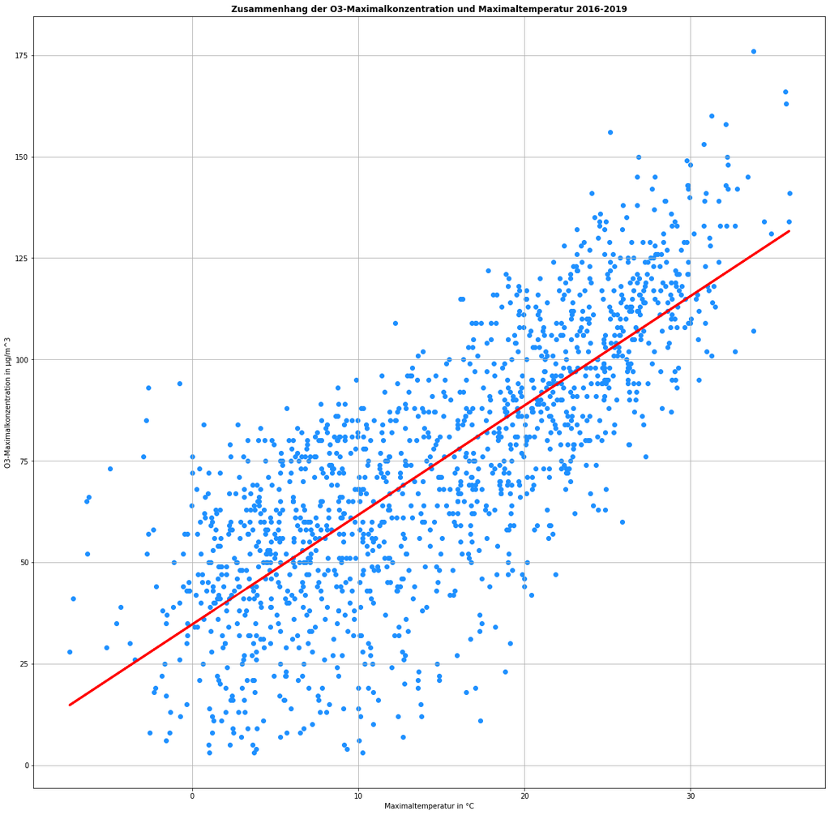

```python
plt.figure(figsize=(20, 20))

# Scatterplot anlegen
plt.scatter(df_corr['x'], df_corr['y'], color='dodgerblue')

# Regressionsgerade mit dem Werten von 'vek_reg' einzeichnen
plt.plot(df_corr['x'], vek_reg, color='red', linewidth=3)

plt.title('Zusammenhang der O3-Maximalkonzentration und Maximaltemperatur 2016-2019', fontdict=dict(fontweight='bold'))

plt.xlabel('Maximaltemperatur in °C')
plt.ylabel('O3-Maximalkonzentration in µg/m^3')

plt.grid()

plt.show()
```

## Aufgabe 8:

> *Einfluss der Coronavirus-Pandemie auf die Luftqualität*  
> **Zurück zur Gliederung**

**a) Daten beziehen**

```python
# Prüfen, ob die Daten bereits als CSV Datei vorliegen
if (path.exists('cache/data_cor.csv')):
    data_cor = pd.read_csv('cache/data_cor.csv')
else:
    # Definiere die spezifischen URL-Parameter
    # Scope-ID: 2 = One hour average (siehe https://www.umweltbundesamt.de/api/air_data/v2/scopes/json)
    # Component-ID: 5 = Nitrogen dioxide (siehe https://www.umweltbundesamt.de/api/air_data/v2/components/json)
    payload = {'date_from': '2020-01-01', 'date_to': '2020-04-30', 'time_from': '1', 'time_to': '24', 'component': '5', 'scope': '2', 'station': ''}

    # Aus Performancegründen eine leere temporäre Liste zum Speichern der einzelnen erhaltenen Daten anlegen
    data_temp = []

    # Iterieren über alle bayerischen Stationen
    for id in stations_BY['Id of station']:

        # Station-ID für die API Abfrage aktualisieren
        payload['station'] = id

        # POST-HTTP-Request mit oben vordefinirten Parametern
        response = requests.post('https://www.umweltbundesamt.de/api/air_data/v2/measures/json', params=payload).json()

        # Zwischenspeichern der erhaltenen Daten
        data = response['data']

        # Checken, ob die zurückgelieferten Daten vorhanden sind, falls nicht mit NaN in temporäre Liste 'data_temp' speichern
        if not data:
            data_temp.append([id, 'NaN', 'NaN'])
            continue # Nächste Iteration durchführen

        # Über alle Schlüssel (Datum mit Uhrzeit) iterieren und Werte in temporäre Liste 'data_temp' speichern
        for datetime in data[str(id)].keys():
            data_temp.append([str(id), datetime, data[str(id)][datetime][2]])

    # DataFrame "data_cor" aus oben angelegter temporärer Liste 'data_cor' erstellen
    # Grund dafür, dass ich erst jetzt den DataFrame erstelle und nicht am Anfang ist die bessere Performance der .append()-Methode normaler Listen ggü. DataFrames
    data_cor = pd.DataFrame(data_temp, columns=['STATION_ID', 'DT', 'NO2'])

    # Als CSV Datei abspeichern, sodass beim nächsten Durchlauf data_no2 um einiges schneller geladen werden kann
    data_cor.to_csv('cache/data_cor.csv', index=False)

# DataFrame ausgeben
data_cor
```

|  | STATION_ID | DT | NO2 |
| --- | --- | --- | --- |
| 0 | 435 | 2020-01-01 00:00:00 | 32.0 |
| 1 | 435 | 2020-01-01 01:00:00 | 31.0 |
| 2 | 435 | 2020-01-01 02:00:00 | 34.0 |
| 3 | 435 | 2020-01-01 03:00:00 | 34.0 |
| 4 | 435 | 2020-01-01 04:00:00 | 35.0 |
| ... | ... | ... | ... |
| 136490 | 615 | 2020-04-30 19:00:00 | 6.0 |
| 136491 | 615 | 2020-04-30 20:00:00 | 4.0 |
| 136492 | 615 | 2020-04-30 21:00:00 | 6.0 |
| 136493 | 615 | 2020-04-30 22:00:00 | 2.0 |
| 136494 | 615 | 2020-04-30 23:00:00 | 8.0 |

136495 rows × 3 columns

**b) Daten aufbereiten**

Den Datentyp der Spalte `NO2` auf `float` und den Datentyp der Spalte `DT` in ein DateTime-Format umwandeln. Zudem werden alle Zeilen gelöscht, in denen ein nicht sinnvoller Wert steht.

```python
# Datentyp von DT und NO2 entsprechend ändern
data_cor = data_cor.astype({'DT' : 'datetime64', 'NO2' : 'float'})

# Vorherherige Zeilenanzahl in Variable speichern, sodass der spätere Wert damit verglichen werden kann
row_count_before = data_cor.shape[0]

# Alle nicht vorhandenen Werte der Spalte "NO2" löschen
data_cor.dropna(subset=['NO2'], how='all', inplace=True)

# Neue Zeilenanzahl nach Löschen der Werte in neue Variable speichern
row_count_after = data_cor.shape[0]

# Entfernte Zeilen ausgeben
deleted_values = row_count_before - row_count_after

print('Es wurden insgesamt ' + str(deleted_values) + ' Einträge entfernt.')
```

```
Es wurden insgesamt 3311 Einträge entfernt.
```

**c) Daten analysieren**

Aufstellen von Hypothesen mit anschließender Akquirierung & Auswertung.

### Hypothese 1

> Betrachtet wird im Folgenden die Station mit der im Durchschnitt höchsten NO2-Konzentration - "München/Landshuter Allee" (ID: 535).  
> *\"In der Woche des Starts der Ausgangsbeschränkung in Bayern ist eine deutliche Auswirkung auf die NO2-Konzentration erkennbar.\"*  
> **Zurück zur Aufgabestellung**

```python
#              #
# =-- 2020 --= #
#              #

# Station 535 (München/Landshuter Allee) aus DataFrame filtern
data_535_cor = data_cor.loc[data_cor['STATION_ID'] == 535]

# Tag, Monat und Jahr als Variable aus den Daten der Spalte "DT" anlegen
day = data_535_cor['DT'].dt.day
month = data_535_cor['DT'].dt.month
year = data_535_cor['DT'].dt.year

# Filtern nach allen Werten im Zeitraum vom 18. März bis 25. März 2020 (Woche des Lockdowns)
data_535_cor = data_535_cor.loc[(year == 2020) & (month == 3) & (day >= 18) & (day <= 25)]

# Nach Tagen gruppieren und Tagesmittelwert berechnen
data_535_cor = data_535_cor.set_index('DT').groupby(pd.Grouper(freq='D')).mean()

data_535_cor
```

| DT | STATION_ID | NO2 |
| --- | --- | --- |
| 2020-03-18 | 535 | 58.750000 |
| 2020-03-19 | 535 | 55.750000 |
| 2020-03-20 | 535 | 64.416667 |
| 2020-03-21 | 535 | 15.958333 |
| 2020-03-22 | 535 | 6.958333 |
| 2020-03-23 | 535 | 17.375000 |
| 2020-03-24 | 535 | 22.375000 |
| 2020-03-25 | 535 | 18.375000 |

```python
#              #
# =-- 2019 --= #
#              #

# Station 535 (München/Landshuter Allee) aus DataFrame filtern
data_535_norm = data_no2.loc[data_no2['STATION_ID'] == 535]

# Tag, Monat und Jahr als Variable aus den Daten der Spalte "DT" anlegen
day = data_535_norm['DT'].dt.day
month = data_535_norm['DT'].dt.month
year = data_535_norm['DT'].dt.year

# Filtern nach allen Werten im Zeitraum vom 18. März bis 25. März 2020 (Woche des Lockdowns)
data_535_norm = data_535_norm.loc[(year == 2019) & (month == 3) & (day >= 18) & (day <= 25)]

# Jahr auf 2020 ändern, sodass es später im Plot richtig dargestellt wird
data_535_norm['DT'] = pd.to_datetime(data_535_norm['DT'].dt.strftime("2020-%m-%d %H:%M:%S"))

# Nach Tagen gruppieren und Tagesmittelwert berechnen
data_535_norm = data_535_norm.set_index('DT').groupby(pd.Grouper(freq='D')).mean()

data_535_norm
```

| DT | STATION_ID | NO2 |
| --- | --- | --- |
| 2020-03-18 | 535 | 66.375000 |
| 2020-03-19 | 535 | 76.000000 |
| 2020-03-20 | 535 | 72.272727 |
| 2020-03-21 | 535 | 61.666667 |
| 2020-03-22 | 535 | 77.500000 |
| 2020-03-23 | 535 | 93.083333 |
| 2020-03-24 | 535 | 72.833333 |
| 2020-03-25 | 535 | 63.166667 |

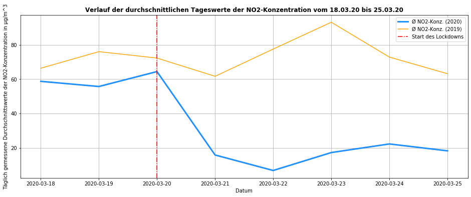

```python
plt.figure(figsize=(16, 6))

# Liniendiagramm mit den Daten aus dem Jahr 2020 (während des Lockdowns) einzeichnen
plt.plot(data_535_cor['NO2'], label='Ø NO2-Konz. (2020)', color='dodgerblue', linewidth='3')

# Liniendiagramm mit den Daten aus dem Jahr 2019 (gleicher Zeitraum, nur ein Jahr zuvor) einzeichnen
plt.plot(data_535_norm['NO2'], label='Ø NO2-Konz. (2019)', color='orange')

# Vertikale Linie an dem Datum des Starts des Lockdowns einzeichnen
plt.axvline(pd.to_datetime("2020-03-20"), color='red', label='Start des Lockdowns', linewidth='1.5', linestyle='dashdot')

plt.legend()

plt.title('Verlauf der durchschnittlichen Tageswerte der NO2-Konzentration vom 18.03.20 bis 25.03.20', fontdict=dict(fontweight='bold'))

plt.xlabel('Datum')
plt.ylabel('Täglich gemessene Durchschnittswerte der NO2-Konzentration in µg/m^3')

plt.grid()

plt.show()
```

### Auswertung der Aufgabe 8c) / Hypothese 1

Dieses Diagramm zeigt zwei verschieden farbige Linien, welche jeweils für die durchschnittlichen Tagesmesswerte der NO2-Konzentration im Zeitraum vom 18.03.2020 bis 25.03.2020 stehen. Anhand der blau dargestellten Linie lässt sich ziemlich gut erkennen, dass zwischen dem 20.03.2020 und 21.03.2020 ein deutlicher Abfall der NO2-Werte zu verzeichnen war. Zwischen genau diesen zwei Tagen trat die Ausgangsbeschränkung in Bayern in Kraft.  
Mit Vergleich zum Vorjahr ist dieser Abfall der NO2-Werte also kein Zufall, sondern hat direkten Zusammenhang mit dem Lockdown in Bayern.  
Ein weiterer Grund für den direkten Zusammenhang ist, dass die NO2-Konzentration der Folgetage auf stetig niedrigen Werten bleibt.